# Reproducible Research: Peer Assessment 1

## Loading and preprocessing the data

```r
library(lattice)
mydata <- read.csv('activity.csv',sep = ",",header = TRUE, na.strings ="NA",colClasses = c('numeric','Date','numeric'))

mydatanew<-na.omit(mydata)
```

## What is mean total number of steps taken per day?

### 1. Make a histogram of the total number of steps taken each day

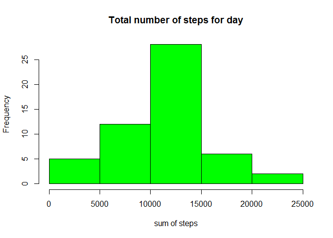

```r
tsteps <- aggregate(steps ~ date, mydatanew, sum)
hist(tsteps$steps , main = "Total number of steps for day", xlab = "sum of steps", col = "green")
```

### 2. Calculate and report the mean and median total number of steps taken per day

```r
tstepsDayMean <- mean(tsteps$steps)
print(sprintf("Mean of steps per day: %f ", tstepsDayMean))
```

```
## [1] "Mean of steps per day: 10766.188679 "
```

```r
tstepsDayMedian <- median(tsteps$steps)
print(sprintf("Median of steps per day: %f ", tstepsDayMedian))
```

```
## [1] "Median of steps per day: 10765.000000 "
```

## What is the average daily activity pattern?

### 1. Make a time series plot (i.e. type = “l”) of the 5-minute interval (x-axis) and the average number of steps taken, averaged across all days (y-axis)

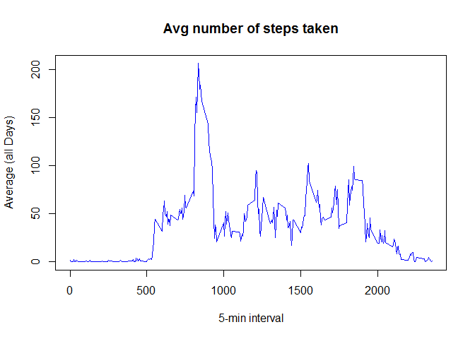

```r
timeseriesplot <- tapply(mydatanew$steps, mydatanew$interval, mean)

plot(row.names(timeseriesplot), timeseriesplot, type = "l", xlab = "5-min interval",
     ylab = "Average (all Days)", main = "Avg number of steps taken",
     col = "blue")
```

### 2. Which 5-minute interval, on average across all the days in the dataset, contains the maximum number of steps?

```r
max<- which.max(timeseriesplot)
names(max)
```

```
## [1] "835"
```

## Imputing missing values

### 1. Calculate and report the total number of missing values in the dataset (i.e. the total number of rows with NAs)

```r
NosofRowswithNA <- sum(is.na(mydata))
NosofRowswithNA
```

```
## [1] 2304
```

### 2. Devise a strategy for filling in all of the missing values in the dataset. The strategy does not need to be sophisticated. For example, you could use the mean/median for that day, or the mean for that 5-minute interval, etc.

```r
mydataimputed<-mydata
tstepsDayMean <- aggregate(steps ~ interval, data = mydata, FUN = mean)
## will use the mean values to fill in the NA values in the mydata
```